# mpltest

```python
        ax.text(1, 0, 'All rates: $\lambda = .1$')
        ax.text(2,1, 'Results apply for defender window of 2, 3 and 4')
        ax.axis('equal')
        ax.axis('off')
        ax.text(1,1.2, '1', fontsize=12)
        ax.text(1.5, 3.2, '1', fontsize=12)
        ax.text(-2, 2.2, '2', fontsize=12)
        ax.text(-1.5, 3.2, '3', fontsize=12)
        ax.text(-1, 2.2, '2', fontsize=12)
    elif scenario == 'Scenario 4':
        ev = ['Nothing', 'A-B', 'B-E', 'E-J', 'J-L', 'Nothing' , 'Nothing', 'Nothing', 'Nothing', \
              'Nothing', 'Nothing','Nothing','Nothing', 'B-F', 'A-D', 'D-I', 'D-L']
        node_x = [0, -1, 0, 1, -2, -1, 0, 1, 2, -1.5, 0, 1.5, -1.5,1.5]
        node_y = [0, 1, 1, 1, 2,2,2,2,2,3,3,3,4,4]
        fig, ax = plt.subplots()
        if ix >= len(ev):
            ax.scatter(node_x, node_y, alpha =.1)
            ax.text(-2.5, 0, 'Rewind slider to watch again')
            plt.axis('equal')
            return fig
        hour = ['0', '1', '1', '1', '1','2', '2', '2', '2', '3', '3', '3', '3', '4', '4', '4', '4']
        ix_color_dict = {
        0:['red'] + ['blue']*13,
        1: ['red'] * 2 + ['blue']*12,
        2: ['red']*2 + ['blue']*2 + ['red']*1 + ['blue']*9,
        3: ['red']*2 + ['blue']*2 + ['red'] + ['blue']*4 + ['red'] + ['blue']*4,
        4: ['red']*2 + ['blue']*2 + ['red'] + ['blue']*4  + ['red']*1 + ['blue']*2 + ['red'] + ['blue'],
        5: ['red']*2 + ['blue']*2 + ['red'] + ['blue']*4  + ['red']*1 + ['blue']*2 + ['red'] + ['blue'],
        6: ['red']*2 + ['blue']*2 + ['red'] + ['blue']*4  + ['red']*1 + ['blue']*2 + ['red'] + ['blue'],
        7: ['red']*2 + ['blue']*2 + ['red'] + ['blue']*4  + ['red']*1 + ['blue']*2 + ['red'] + ['blue'],
        8: ['red']*2 + ['blue']*2 + ['red'] + ['blue']*4  + ['red']*1 + ['blue']*2 + ['red'] + ['blue'],
        9: ['red']*2 + ['blue']*2 + ['red'] + ['blue']*4  + ['red']*1 + ['blue']*2 + ['red'] + ['blue'],
        10: ['red']*2 + ['blue']*2 + ['red'] + ['blue']*4  + ['red']*1 + ['blue']*2 + ['red'] + ['blue'],
        11: ['red']*2 + ['blue']*2 + ['red'] + ['blue']*4  + ['red']*1 + ['blue']*2 + ['red'] + ['blue'],
        12: ['red']*2 + ['blue']*2 + ['red'] + ['blue']*4  + ['red']*1 + ['blue']*2 + ['red'] + ['blue'],
        13: ['red']*2 + ['blue']*1 + ['red']*2 + ['blue']*4  + ['red']*1 + ['blue']*2 + ['red'] + ['blue'],
        14: ['red']*2 + ['blue']*1 + ['red']*2 + ['blue']*3  + ['red']*2 + ['blue']*2 + ['red'] + ['blue'],
        15: ['red']*2 + ['blue']*1 + ['red']*2 + ['blue']*3  + ['red']*2 + ['blue']*1 + ['red']*2 + ['blue'],
        16: ['red']*2 + ['blue']*1 + ['red']*2 + ['blue']*3  + ['red']*2 + ['blue']*1 + ['red']*3 + ['blue']*0
    }
        ax.scatter(node_x, node_y, s=[100]*14, color = ix_color_dict[ix])
        ax.arrow(0, 0, -1, 1, color='black', head_width=.1,
                     length_includes_head=True, alpha=.3)
        ax.arrow(0, 0, 0, 1, color='black', head_width=.1,
                     length_includes_head=True, alpha=.3)
        ax.arrow(0, 0, 1, 1, color='black', head_width=.1,
                     length_includes_head=True, alpha=.3)
        ax.arrow(-1, 1, -1, 1, color='black', head_width=.1,
                     length_includes_head=True, alpha=.3)
        ax.arrow(-1, 1, 0, 1, color='black', head_width=.1,
                     length_includes_head=True, alpha=.3)
        ax.arrow(-1, 1, 1, 1, color='black', head_width=.1,
                     length_includes_head=True, alpha=.3)
        ax.arrow(-2, 2, .5, 1, color='black', head_width=.1,
                     length_includes_head=True, alpha=.3)
        ax.arrow(-1, 2, -.5, 1, color='black', head_width=.1,
                    length_includes_head=True, alpha=.3)
        ax.arrow(0, 1, 0, 1, color='black', head_width=.1,
                length_includes_head=True, alpha=.3)
        ax.arrow(0, 2, 0, 1, color='black', head_width=.1,
                     length_includes_head=True, alpha=.3)
        ax.arrow(-1, 2, 1, 1, color='black', head_width=.1,
                     length_includes_head=True, alpha=.3)
        ax.arrow(1, 1, 0, 1, color='black', head_width=.1,
                     length_includes_head=True, alpha=.3)
        ax.arrow(1, 1, 1, 1, color='black', head_width=.1,
                     length_includes_head=True, alpha=.3)
        ax.arrow(1, 1, -1, 1, color='black', head_width=.1,
                     length_includes_head=True, alpha=.3)
        ax.arrow(1, 2, .5, 1, color='black', head_width=.1,
                     length_includes_head=True, alpha=.3)
        ax.arrow(2, 2, -.5, 1, color='black', head_width=.1,
                     length_includes_head=True, alpha=.3)
        ax.arrow(1, 2, -1, 1, color='black', head_width=.1,
                     length_includes_head=True, alpha=.3)
        ax.arrow(-1.5, 3, 0, 1, color='black', head_width=.1,
                     length_includes_head=True, alpha=.3)
        ax.arrow(1.5, 3, 0, 1, color='black', head_width=.1,
                     length_includes_head=True, alpha=.3)
        ax.text(-2, 0 , 'Hour =' + str(hour[ix]), fontsize=18)

        ax.text(1, 0, 'All rates: $\lambda = .05$')
        ax.text(2,1, 'Defender window = 2')
        ax.axis('equal')
        ax.axis('off')
        ax.text(1.5,4.2, '1', fontsize=12)
        ax.text(-1.5, 4.2, '1', fontsize=12)
        if ix >= 5 and ix <= 12:
            ax.text(2, 3, 'Attacker Waits', fontsize=18)

    return fig
```

# Parameter Sweeps

Use the interactive plots below to see the results for various parameter specifications. The slider varies time while the dropdown box brings up different experiments. The first experiment is the one I presented in the last meeting. That is the only one where the probabilities of infection are not homogeneous. Other notes:

- With the exception of the first model, the probability fo infection upon receiving a malicious message is 1 for all nodes. (This incorporates Josh's note from last meeting)
- Numbers on (or near) green nodes are the attacker's reward for infecting that node.
- The attacker still keeps a complete memory
- The attacker's memory is on a per-hour basis. That is, he remembers the messages he sent (along each edge) in the first hour, second hour, third hour etc.
- The attacker has the opportunity to send a message at a rate of 4 messages per hour.
- Each tick of the slider represents an attacker's opportunity to send a message.

```python
evnts = RangeWidget(0,20,1)
scenario = DropDownWidget(['Scenario 1', 'Scenario 2', 'Scenario 3', 'Scenario 4'])
```

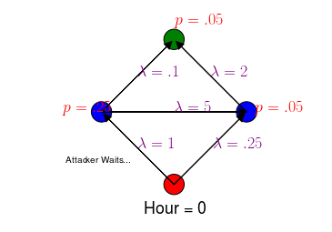

**Attacker_Event:**  
**scenario:**

```python
StaticInteract(plot, Attacker_Event=evnts, scenario=scenario)
```

# Notes/Issues

- Results sensitive to UCT parameter and rollout --- Requires hand tuning for each action-state
- Finding full policy can take up to 12 hours (but can be less).
- An infection probability of 1 greatly **reduces** the state space!

# Next Steps

- Pick **1** network topology
- For various UCT and rollout settings, compute the optimal full policy
- Out of those, simulate the network to get the policy that yields the highest expected utility
- Run "level-K" experiment where the attacker models the defender's level 0 as having a simple anomaly detector. However, the defender actually uses a likelihood ratio, derived from the optimal attacker's strategy.
- Note: with the new infection probability of 1, the likelihood is going to change...I think. In other words, instead of integrating over the infection times, we integrate over the attacker's action times. If we know the action times, the computed optimal strategy gives us the infection times.
- Note: WIth the current setup, it looks like we will be leaning toward a moving window attack detector. This was different than our original ROC curves.